# Risk Factor Analysis

## Outcome Variable

**Outcome Variable:** wasted

## Predictor Variables

**Intervention Variable:** birthlen

**Adjustment Set:**

- arm
- sex
- W_mage
- meducyrs
- feducyrs
- vagbrth
- single
- brthmon
- W_parity
- delta_W_mage
- delta_meducyrs
- delta_feducyrs
- delta_vagbrth
- delta_single
- delta_brthmon
- delta_W_parity

## Stratifying Variables

The analysis was stratified on these variable(s):

- agecat
- studyid
- country

## Data Summary

| agecat | studyid | country | birthlen | wasted | n_cell | n |
| --- | --- | --- | --- | --- | --- | --- |
| Birth | CMC-V-BCS-2002 | INDIA | >=50 cm | 0 | 12 | 86 |
| Birth | CMC-V-BCS-2002 | INDIA | >=50 cm | 1 | 1 | 86 |
| Birth | CMC-V-BCS-2002 | INDIA | <48 cm | 0 | 27 | 86 |
| Birth | CMC-V-BCS-2002 | INDIA | <48 cm | 1 | 6 | 86 |
| Birth | CMC-V-BCS-2002 | INDIA | [48-50) cm | 0 | 36 | 86 |
| Birth | CMC-V-BCS-2002 | INDIA | [48-50) cm | 1 | 4 | 86 |
| Birth | CMIN | BANGLADESH | >=50 cm | 0 | 1 | 19 |
| Birth | CMIN | BANGLADESH | >=50 cm | 1 | 1 | 19 |
| Birth | CMIN | BANGLADESH | <48 cm | 0 | 6 | 19 |
| Birth | CMIN | BANGLADESH | <48 cm | 1 | 3 | 19 |
| Birth | CMIN | BANGLADESH | [48-50) cm | 0 | 8 | 19 |
| Birth | CMIN | BANGLADESH | [48-50) cm | 1 | 0 | 19 |
| Birth | COHORTS | GUATEMALA | >=50 cm | 0 | 260 | 756 |
| Birth | COHORTS | GUATEMALA | >=50 cm | 1 | 136 | 756 |
| Birth | COHORTS | GUATEMALA | <48 cm | 0 | 120 | 756 |
| Birth | COHORTS | GUATEMALA | <48 cm | 1 | 12 | 756 |
| Birth | COHORTS | GUATEMALA | [48-50) cm | 0 | 184 | 756 |
| Birth | COHORTS | GUATEMALA | [48-50) cm | 1 | 44 | 756 |
| Birth | COHORTS | INDIA | >=50 cm | 0 | 1102 | 6193 |
| Birth | COHORTS | INDIA | >=50 cm | 1 | 302 | 6193 |
| Birth | COHORTS | INDIA | <48 cm | 0 | 1992 | 6193 |
| Birth | COHORTS | INDIA | <48 cm | 1 | 362 | 6193 |
| Birth | COHORTS | INDIA | [48-50) cm | 0 | 2003 | 6193 |
| Birth | COHORTS | INDIA | [48-50) cm | 1 | 432 | 6193 |
| Birth | COHORTS | PHILIPPINES | >=50 cm | 0 | 864 | 2899 |
| Birth | COHORTS | PHILIPPINES | >=50 cm | 1 | 246 | 2899 |
| Birth | COHORTS | PHILIPPINES | <48 cm | 0 | 571 | 2899 |
| Birth | COHORTS | PHILIPPINES | <48 cm | 1 | 80 | 2899 |
| Birth | COHORTS | PHILIPPINES | [48-50) cm | 0 | 1013 | 2899 |
| Birth | COHORTS | PHILIPPINES | [48-50) cm | 1 | 125 | 2899 |

[output cut: 426 more lines]

The following strata were considered:

- agecat: 24 months, studyid: CMC-V-BCS-2002, country: INDIA
- agecat: 24 months, studyid: CMIN, country: BANGLADESH
- agecat: 24 months, studyid: COHORTS, country: GUATEMALA
- agecat: 24 months, studyid: COHORTS, country: INDIA
- agecat: 24 months, studyid: COHORTS, country: PHILIPPINES
- agecat: 24 months, studyid: CONTENT, country: PERU
- agecat: 24 months, studyid: EE, country: PAKISTAN
- agecat: 24 months, studyid: GMS-Nepal, country: NEPAL
- agecat: 24 months, studyid: IRC, country: INDIA
- agecat: 24 months, studyid: JiVitA-3, country: BANGLADESH
- agecat: 24 months, studyid: JiVitA-4, country: BANGLADESH
- agecat: 24 months, studyid: Keneba, country: GAMBIA
- agecat: 24 months, studyid: MAL-ED, country: BANGLADESH
- agecat: 24 months, studyid: MAL-ED, country: BRAZIL
- agecat: 24 months, studyid: MAL-ED, country: INDIA
- agecat: 24 months, studyid: MAL-ED, country: NEPAL
- agecat: 24 months, studyid: MAL-ED, country: PERU
- agecat: 24 months, studyid: MAL-ED, country: SOUTH AFRICA
- agecat: 24 months, studyid: MAL-ED, country: TANZANIA, UNITED REPUBLIC OF
- agecat: 24 months, studyid: NIH-Birth, country: BANGLADESH
- agecat: 24 months, studyid: NIH-Crypto, country: BANGLADESH
- agecat: 24 months, studyid: PROBIT, country: BELARUS
- agecat: 24 months, studyid: PROVIDE, country: BANGLADESH
- agecat: 24 months, studyid: ZVITAMBO, country: ZIMBABWE
- agecat: 6 months, studyid: CMC-V-BCS-2002, country: INDIA
- agecat: 6 months, studyid: CMIN, country: BANGLADESH
- agecat: 6 months, studyid: COHORTS, country: GUATEMALA
- agecat: 6 months, studyid: COHORTS, country: INDIA
- agecat: 6 months, studyid: COHORTS, country: PHILIPPINES
- agecat: 6 months, studyid: CONTENT, country: PERU
- agecat: 6 months, studyid: EE, country: PAKISTAN
- agecat: 6 months, studyid: GMS-Nepal, country: NEPAL
- agecat: 6 months, studyid: IRC, country: INDIA
- agecat: 6 months, studyid: JiVitA-3, country: BANGLADESH
- agecat: 6 months, studyid: JiVitA-4, country: BANGLADESH
- agecat: 6 months, studyid: Keneba, country: GAMBIA
- agecat: 6 months, studyid: MAL-ED, country: BANGLADESH
- agecat: 6 months, studyid: MAL-ED, country: BRAZIL
- agecat: 6 months, studyid: MAL-ED, country: INDIA
- agecat: 6 months, studyid: MAL-ED, country: NEPAL
- agecat: 6 months, studyid: MAL-ED, country: PERU
- agecat: 6 months, studyid: MAL-ED, country: SOUTH AFRICA
- agecat: 6 months, studyid: MAL-ED, country: TANZANIA, UNITED REPUBLIC OF
- agecat: 6 months, studyid: NIH-Birth, country: BANGLADESH
- agecat: 6 months, studyid: NIH-Crypto, country: BANGLADESH
- agecat: 6 months, studyid: PROBIT, country: BELARUS
- agecat: 6 months, studyid: PROVIDE, country: BANGLADESH
- agecat: 6 months, studyid: ResPak, country: PAKISTAN
- agecat: 6 months, studyid: SAS-CompFeed, country: INDIA
- agecat: 6 months, studyid: ZVITAMBO, country: ZIMBABWE
- agecat: Birth, studyid: CMC-V-BCS-2002, country: INDIA
- agecat: Birth, studyid: CMIN, country: BANGLADESH
- agecat: Birth, studyid: COHORTS, country: GUATEMALA
- agecat: Birth, studyid: COHORTS, country: INDIA
- agecat: Birth, studyid: COHORTS, country: PHILIPPINES
- agecat: Birth, studyid: CONTENT, country: PERU
- agecat: Birth, studyid: EE, country: PAKISTAN
- agecat: Birth, studyid: GMS-Nepal, country: NEPAL
- agecat: Birth, studyid: IRC, country: INDIA
- agecat: Birth, studyid: JiVitA-3, country: BANGLADESH
- agecat: Birth, studyid: JiVitA-4, country: BANGLADESH
- agecat: Birth, studyid: Keneba, country: GAMBIA
- agecat: Birth, studyid: MAL-ED, country: BANGLADESH
- agecat: Birth, studyid: MAL-ED, country: BRAZIL
- agecat: Birth, studyid: MAL-ED, country: INDIA
- agecat: Birth, studyid: MAL-ED, country: NEPAL
- agecat: Birth, studyid: MAL-ED, country: PERU
- agecat: Birth, studyid: MAL-ED, country: SOUTH AFRICA
- agecat: Birth, studyid: MAL-ED, country: TANZANIA, UNITED REPUBLIC OF
- agecat: Birth, studyid: NIH-Birth, country: BANGLADESH
- agecat: Birth, studyid: NIH-Crypto, country: BANGLADESH
- agecat: Birth, studyid: PROBIT, country: BELARUS
- agecat: Birth, studyid: PROVIDE, country: BANGLADESH
- agecat: Birth, studyid: ResPak, country: PAKISTAN
- agecat: Birth, studyid: SAS-CompFeed, country: INDIA
- agecat: Birth, studyid: ZVITAMBO, country: ZIMBABWE

### Dropped Strata

Some strata were dropped due to rare outcomes:

- agecat: Birth, studyid: CMC-V-BCS-2002, country: INDIA
- agecat: Birth, studyid: CMIN, country: BANGLADESH
- agecat: Birth, studyid: CONTENT, country: PERU
- agecat: Birth, studyid: EE, country: PAKISTAN
- agecat: Birth, studyid: MAL-ED, country: BRAZIL
- agecat: Birth, studyid: MAL-ED, country: INDIA
- agecat: Birth, studyid: MAL-ED, country: NEPAL
- agecat: Birth, studyid: MAL-ED, country: PERU
- agecat: Birth, studyid: MAL-ED, country: SOUTH AFRICA
- agecat: Birth, studyid: MAL-ED, country: TANZANIA, UNITED REPUBLIC OF
- agecat: Birth, studyid: PROBIT, country: BELARUS
- agecat: Birth, studyid: ResPak, country: PAKISTAN
- agecat: 6 months, studyid: CMC-V-BCS-2002, country: INDIA
- agecat: 6 months, studyid: CMIN, country: BANGLADESH
- agecat: 6 months, studyid: COHORTS, country: GUATEMALA
- agecat: 6 months, studyid: CONTENT, country: PERU
- agecat: 6 months, studyid: EE, country: PAKISTAN
- agecat: 6 months, studyid: MAL-ED, country: BANGLADESH
- agecat: 6 months, studyid: MAL-ED, country: BRAZIL
- agecat: 6 months, studyid: MAL-ED, country: INDIA
- agecat: 6 months, studyid: MAL-ED, country: NEPAL
- agecat: 6 months, studyid: MAL-ED, country: PERU
- agecat: 6 months, studyid: MAL-ED, country: SOUTH AFRICA
- agecat: 6 months, studyid: MAL-ED, country: TANZANIA, UNITED REPUBLIC OF
- agecat: 6 months, studyid: NIH-Crypto, country: BANGLADESH
- agecat: 6 months, studyid: PROBIT, country: BELARUS
- agecat: 6 months, studyid: PROVIDE, country: BANGLADESH
- agecat: 6 months, studyid: ResPak, country: PAKISTAN
- agecat: 24 months, studyid: CMC-V-BCS-2002, country: INDIA
- agecat: 24 months, studyid: CMIN, country: BANGLADESH
- agecat: 24 months, studyid: COHORTS, country: GUATEMALA
- agecat: 24 months, studyid: CONTENT, country: PERU
- agecat: 24 months, studyid: EE, country: PAKISTAN
- agecat: 24 months, studyid: MAL-ED, country: BANGLADESH
- agecat: 24 months, studyid: MAL-ED, country: BRAZIL
- agecat: 24 months, studyid: MAL-ED, country: INDIA
- agecat: 24 months, studyid: MAL-ED, country: NEPAL
- agecat: 24 months, studyid: MAL-ED, country: PERU
- agecat: 24 months, studyid: MAL-ED, country: SOUTH AFRICA
- agecat: 24 months, studyid: MAL-ED, country: TANZANIA, UNITED REPUBLIC OF
- agecat: 24 months, studyid: PROBIT, country: BELARUS

## Methods Detail

We’re interested in the causal parameters $E[Y_a]$ for all values of $a \in \mathcal{A}$. These parameters represent the mean outcome if, possibly contrary to fact, we intervened to set all units to have $A=a$. Under the randomization and positivity assumptions, these are identified by the statistical parameters $\psi_a=E_W[E_{Y|A,W}(Y|A=a,W)]$. In addition, we’re interested in the mean of $Y$, $E[Y]$ under no intervention (the observed mean). We will estimate these parameters by using SuperLearner to fit the relevant likelihood factors – $E_{Y|A,W}(Y|A=a,W)$ and $p(A=a|W)$, and then updating our likelihood fit using a joint TMLE.

For unadjusted analyses ($W=\{\}$), initial likelihoods were estimated using Lrnr_glm to estimate the simple $E(Y|A)$ and Lrnr_mean to estimate $p(A)$. For adjusted analyses, a small library containing Lrnr_glmnet, Lrnr_xgboost, and Lrnr_mean was used.

Having estimated these parameters, we will then use the delta method to estimate relative risks and attributable risks relative to a prespecified baseline level of $A$.

# Results Detail

## Results Plots

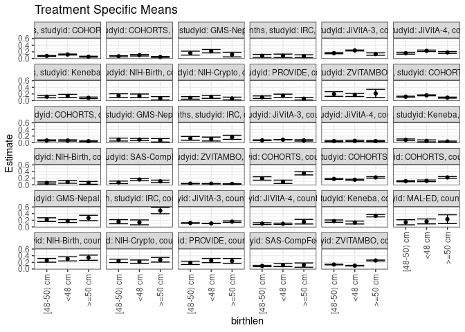

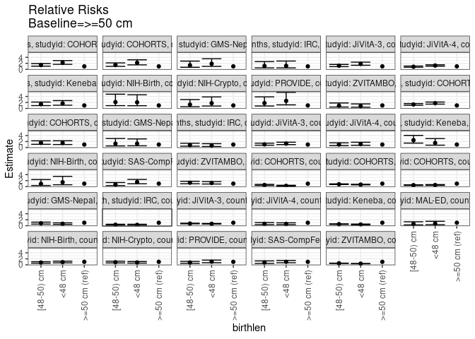

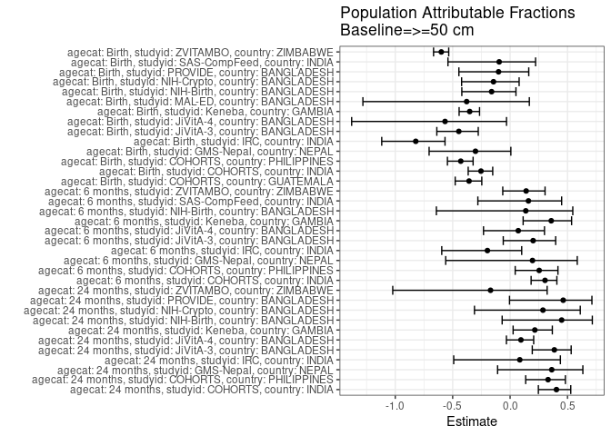

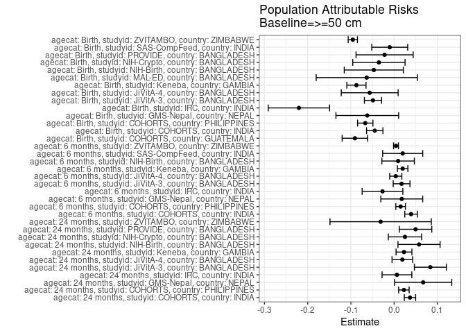

## Results Table

### Parameter: TSM

| agecat | studyid | country | intervention_level | baseline_level | estimate | ci_lower | ci_upper |
| --- | --- | --- | --- | --- | --- | --- | --- |
| Birth | COHORTS | GUATEMALA | >=50 cm | NA | 0.3447157 | 0.2978081 | 0.3916233 |
| Birth | COHORTS | GUATEMALA | <48 cm | NA | 0.0902585 | 0.0405525 | 0.1399646 |
| Birth | COHORTS | GUATEMALA | [48-50) cm | NA | 0.1903399 | 0.1386056 | 0.2420741 |
| Birth | COHORTS | INDIA | >=50 cm | NA | 0.2218437 | 0.2000325 | 0.2436548 |
| Birth | COHORTS | INDIA | <48 cm | NA | 0.1521097 | 0.1374532 | 0.1667662 |
| Birth | COHORTS | INDIA | [48-50) cm | NA | 0.1773739 | 0.1619609 | 0.1927868 |
| Birth | COHORTS | PHILIPPINES | >=50 cm | NA | 0.2223922 | 0.1979539 | 0.2468304 |
| Birth | COHORTS | PHILIPPINES | <48 cm | NA | 0.1192200 | 0.0944195 | 0.1440204 |
| Birth | COHORTS | PHILIPPINES | [48-50) cm | NA | 0.1107673 | 0.0923587 | 0.1291759 |
| Birth | GMS-Nepal | NEPAL | >=50 cm | NA | 0.2680188 | 0.1866462 | 0.3493913 |
| Birth | GMS-Nepal | NEPAL | <48 cm | NA | 0.1772432 | 0.1350116 | 0.2194747 |
| Birth | GMS-Nepal | NEPAL | [48-50) cm | NA | 0.2174835 | 0.1611248 | 0.2738423 |
| Birth | IRC | INDIA | >=50 cm | NA | 0.4885697 | 0.3958880 | 0.5812513 |
| Birth | IRC | INDIA | <48 cm | NA | 0.1361582 | 0.0631977 | 0.2091186 |
| Birth | IRC | INDIA | [48-50) cm | NA | 0.1567742 | 0.0948484 | 0.2187001 |
| Birth | JiVitA-3 | BANGLADESH | >=50 cm | NA | 0.1584270 | 0.1373525 | 0.1795015 |
| Birth | JiVitA-3 | BANGLADESH | <48 cm | NA | 0.1039118 | 0.0977388 | 0.1100848 |
| Birth | JiVitA-3 | BANGLADESH | [48-50) cm | NA | 0.1163488 | 0.1063403 | 0.1263574 |
| Birth | JiVitA-4 | BANGLADESH | >=50 cm | NA | 0.1562519 | 0.0869536 | 0.2255502 |
| Birth | JiVitA-4 | BANGLADESH | <48 cm | NA | 0.0945499 | 0.0754064 | 0.1136934 |
| Birth | JiVitA-4 | BANGLADESH | [48-50) cm | NA | 0.0990031 | 0.0722152 | 0.1257910 |
| Birth | Keneba | GAMBIA | >=50 cm | NA | 0.3350001 | 0.3007764 | 0.3692238 |
| Birth | Keneba | GAMBIA | <48 cm | NA | 0.1313899 | 0.0877523 | 0.1750275 |
| Birth | Keneba | GAMBIA | [48-50) cm | NA | 0.1741007 | 0.1403503 | 0.2078511 |
| Birth | MAL-ED | BANGLADESH | >=50 cm | NA | 0.2307692 | 0.0982297 | 0.3633088 |
| Birth | MAL-ED | BANGLADESH | <48 cm | NA | 0.1649485 | 0.0909189 | 0.2389780 |
| Birth | MAL-ED | BANGLADESH | [48-50) cm | NA | 0.1392405 | 0.0627213 | 0.2157597 |
| Birth | NIH-Birth | BANGLADESH | >=50 cm | NA | 0.3392094 | 0.2603383 | 0.4180805 |
| Birth | NIH-Birth | BANGLADESH | <48 cm | NA | 0.3052008 | 0.2430960 | 0.3673055 |
| Birth | NIH-Birth | BANGLADESH | [48-50) cm | NA | 0.2610315 | 0.2039489 | 0.3181142 |

[output cut: 75 more lines]

### Parameter: E(Y)

| agecat | studyid | country | intervention_level | baseline_level | estimate | ci_lower | ci_upper |
| --- | --- | --- | --- | --- | --- | --- | --- |
| Birth | COHORTS | GUATEMALA | NA | NA | 0.2539683 | 0.2229196 | 0.2850169 |
| Birth | COHORTS | INDIA | NA | NA | 0.1769740 | 0.1674681 | 0.1864799 |
| Birth | COHORTS | PHILIPPINES | NA | NA | 0.1555709 | 0.1423748 | 0.1687670 |
| Birth | GMS-Nepal | NEPAL | NA | NA | 0.2059282 | 0.1745993 | 0.2372572 |
| Birth | IRC | INDIA | NA | NA | 0.2682216 | 0.2212677 | 0.3151755 |
| Birth | JiVitA-3 | BANGLADESH | NA | NA | 0.1095259 | 0.1044047 | 0.1146471 |
| Birth | JiVitA-4 | BANGLADESH | NA | NA | 0.0997496 | 0.0843744 | 0.1151247 |
| Birth | Keneba | GAMBIA | NA | NA | 0.2477816 | 0.2256667 | 0.2698964 |
| Birth | MAL-ED | BANGLADESH | NA | NA | 0.1674419 | 0.1174176 | 0.2174661 |
| Birth | NIH-Birth | BANGLADESH | NA | NA | 0.2921739 | 0.2549711 | 0.3293768 |
| Birth | NIH-Crypto | BANGLADESH | NA | NA | 0.2432815 | 0.2116319 | 0.2749310 |
| Birth | PROVIDE | BANGLADESH | NA | NA | 0.2199248 | 0.1846953 | 0.2551543 |
| Birth | SAS-CompFeed | INDIA | NA | NA | 0.1069810 | 0.0760961 | 0.1378659 |
| Birth | ZVITAMBO | ZIMBABWE | NA | NA | 0.1595572 | 0.1532418 | 0.1658725 |
| 6 months | COHORTS | INDIA | NA | NA | 0.1289375 | 0.1205453 | 0.1373297 |
| 6 months | COHORTS | PHILIPPINES | NA | NA | 0.0592812 | 0.0503704 | 0.0681920 |
| 6 months | GMS-Nepal | NEPAL | NA | NA | 0.0905861 | 0.0668565 | 0.1143158 |
| 6 months | IRC | INDIA | NA | NA | 0.1362468 | 0.1021125 | 0.1703810 |
| 6 months | JiVitA-3 | BANGLADESH | NA | NA | 0.0859055 | 0.0807379 | 0.0910730 |
| 6 months | JiVitA-4 | BANGLADESH | NA | NA | 0.0531809 | 0.0435210 | 0.0628408 |
| 6 months | Keneba | GAMBIA | NA | NA | 0.0549369 | 0.0427642 | 0.0671096 |
| 6 months | NIH-Birth | BANGLADESH | NA | NA | 0.0675676 | 0.0459314 | 0.0892038 |
| 6 months | SAS-CompFeed | INDIA | NA | NA | 0.1240545 | 0.0993302 | 0.1487787 |
| 6 months | ZVITAMBO | ZIMBABWE | NA | NA | 0.0311423 | 0.0274303 | 0.0348542 |
| 24 months | COHORTS | INDIA | NA | NA | 0.0908513 | 0.0826532 | 0.0990495 |
| 24 months | COHORTS | PHILIPPINES | NA | NA | 0.0682747 | 0.0582774 | 0.0782720 |
| 24 months | GMS-Nepal | NEPAL | NA | NA | 0.1851852 | 0.1506144 | 0.2197560 |
| 24 months | IRC | INDIA | NA | NA | 0.0769231 | 0.0504429 | 0.1034032 |
| 24 months | JiVitA-3 | BANGLADESH | NA | NA | 0.2176282 | 0.2067563 | 0.2285000 |
| 24 months | JiVitA-4 | BANGLADESH | NA | NA | 0.2013085 | 0.1867334 | 0.2158836 |
| 24 months | Keneba | GAMBIA | NA | NA | 0.1060038 | 0.0875152 | 0.1244923 |
| 24 months | NIH-Birth | BANGLADESH | NA | NA | 0.1283293 | 0.0960341 | 0.1606245 |
| 24 months | NIH-Crypto | BANGLADESH | NA | NA | 0.0875486 | 0.0630907 | 0.1120065 |
| 24 months | PROVIDE | BANGLADESH | NA | NA | 0.1070812 | 0.0818727 | 0.1322897 |
| 24 months | ZVITAMBO | ZIMBABWE | NA | NA | 0.1830986 | 0.1463297 | 0.2198675 |

### Parameter: RR

| agecat | studyid | country | intervention_level | baseline_level | estimate | ci_lower | ci_upper |
| --- | --- | --- | --- | --- | --- | --- | --- |
| Birth | COHORTS | GUATEMALA | >=50 cm | >=50 cm | 1.0000000 | 1.0000000 | 1.0000000 |
| Birth | COHORTS | GUATEMALA | <48 cm | >=50 cm | 0.2618347 | 0.1483864 | 0.4620196 |
| Birth | COHORTS | GUATEMALA | [48-50) cm | >=50 cm | 0.5521647 | 0.4074936 | 0.7481979 |
| Birth | COHORTS | INDIA | >=50 cm | >=50 cm | 1.0000000 | 1.0000000 | 1.0000000 |
| Birth | COHORTS | INDIA | <48 cm | >=50 cm | 0.6856615 | 0.5975903 | 0.7867125 |
| Birth | COHORTS | INDIA | [48-50) cm | >=50 cm | 0.7995444 | 0.7012681 | 0.9115932 |
| Birth | COHORTS | PHILIPPINES | >=50 cm | >=50 cm | 1.0000000 | 1.0000000 | 1.0000000 |
| Birth | COHORTS | PHILIPPINES | <48 cm | >=50 cm | 0.5360798 | 0.4238568 | 0.6780158 |
| Birth | COHORTS | PHILIPPINES | [48-50) cm | >=50 cm | 0.4980720 | 0.4082099 | 0.6077160 |
| Birth | GMS-Nepal | NEPAL | >=50 cm | >=50 cm | 1.0000000 | 1.0000000 | 1.0000000 |
| Birth | GMS-Nepal | NEPAL | <48 cm | >=50 cm | 0.6613088 | 0.4495422 | 0.9728325 |
| Birth | GMS-Nepal | NEPAL | [48-50) cm | >=50 cm | 0.8114489 | 0.5446703 | 1.2088950 |
| Birth | IRC | INDIA | >=50 cm | >=50 cm | 1.0000000 | 1.0000000 | 1.0000000 |
| Birth | IRC | INDIA | <48 cm | >=50 cm | 0.2786873 | 0.1577793 | 0.4922486 |
| Birth | IRC | INDIA | [48-50) cm | >=50 cm | 0.3208841 | 0.2067210 | 0.4980946 |
| Birth | JiVitA-3 | BANGLADESH | >=50 cm | >=50 cm | 1.0000000 | 1.0000000 | 1.0000000 |
| Birth | JiVitA-3 | BANGLADESH | <48 cm | >=50 cm | 0.6558970 | 0.5681376 | 0.7572125 |
| Birth | JiVitA-3 | BANGLADESH | [48-50) cm | >=50 cm | 0.7344002 | 0.6308655 | 0.8549266 |
| Birth | JiVitA-4 | BANGLADESH | >=50 cm | >=50 cm | 1.0000000 | 1.0000000 | 1.0000000 |
| Birth | JiVitA-4 | BANGLADESH | <48 cm | >=50 cm | 0.6051121 | 0.3715336 | 0.9855385 |
| Birth | JiVitA-4 | BANGLADESH | [48-50) cm | >=50 cm | 0.6336122 | 0.3782034 | 1.0615041 |
| Birth | Keneba | GAMBIA | >=50 cm | >=50 cm | 1.0000000 | 1.0000000 | 1.0000000 |
| Birth | Keneba | GAMBIA | <48 cm | >=50 cm | 0.3922086 | 0.2771081 | 0.5551176 |
| Birth | Keneba | GAMBIA | [48-50) cm | >=50 cm | 0.5197034 | 0.4173829 | 0.6471074 |
| Birth | MAL-ED | BANGLADESH | >=50 cm | >=50 cm | 1.0000000 | 1.0000000 | 1.0000000 |
| Birth | MAL-ED | BANGLADESH | <48 cm | >=50 cm | 0.7147766 | 0.3448378 | 1.4815826 |
| Birth | MAL-ED | BANGLADESH | [48-50) cm | >=50 cm | 0.6033755 | 0.2725003 | 1.3360061 |
| Birth | NIH-Birth | BANGLADESH | >=50 cm | >=50 cm | 1.0000000 | 1.0000000 | 1.0000000 |
| Birth | NIH-Birth | BANGLADESH | <48 cm | >=50 cm | 0.8997416 | 0.6610211 | 1.2246734 |
| Birth | NIH-Birth | BANGLADESH | [48-50) cm | >=50 cm | 0.7695292 | 0.5590128 | 1.0593231 |

[output cut: 75 more lines]

### Parameter: PAR

| agecat | studyid | country | intervention_level | baseline_level | estimate | ci_lower | ci_upper |
| --- | --- | --- | --- | --- | --- | --- | --- |
| Birth | COHORTS | GUATEMALA | >=50 cm | NA | -0.0907475 | -0.1202499 | -0.0612451 |
| Birth | COHORTS | INDIA | >=50 cm | NA | -0.0448697 | -0.0637788 | -0.0259605 |
| Birth | COHORTS | PHILIPPINES | >=50 cm | NA | -0.0668213 | -0.0845882 | -0.0490543 |
| Birth | GMS-Nepal | NEPAL | >=50 cm | NA | -0.0620905 | -0.1346586 | 0.0104776 |
| Birth | IRC | INDIA | >=50 cm | NA | -0.2203481 | -0.2913318 | -0.1493644 |
| Birth | JiVitA-3 | BANGLADESH | >=50 cm | NA | -0.0489011 | -0.0687444 | -0.0290577 |
| Birth | JiVitA-4 | BANGLADESH | >=50 cm | NA | -0.0565023 | -0.1222894 | 0.0092847 |
| Birth | Keneba | GAMBIA | >=50 cm | NA | -0.0872185 | -0.1093956 | -0.0650415 |
| Birth | MAL-ED | BANGLADESH | >=50 cm | NA | -0.0633274 | -0.1803577 | 0.0537030 |
| Birth | NIH-Birth | BANGLADESH | >=50 cm | NA | -0.0470355 | -0.1153708 | 0.0212999 |
| Birth | NIH-Crypto | BANGLADESH | >=50 cm | NA | -0.0351920 | -0.0956960 | 0.0253120 |
| Birth | PROVIDE | BANGLADESH | >=50 cm | NA | -0.0220858 | -0.0881724 | 0.0440008 |
| Birth | SAS-CompFeed | INDIA | >=50 cm | NA | -0.0101699 | -0.0517148 | 0.0313750 |
| Birth | ZVITAMBO | ZIMBABWE | >=50 cm | NA | -0.0955920 | -0.1063144 | -0.0848695 |
| 6 months | COHORTS | INDIA | >=50 cm | NA | 0.0392181 | 0.0246257 | 0.0538105 |
| 6 months | COHORTS | PHILIPPINES | >=50 cm | NA | 0.0150232 | 0.0039209 | 0.0261256 |
| 6 months | GMS-Nepal | NEPAL | >=50 cm | NA | 0.0176695 | -0.0307949 | 0.0661339 |
| 6 months | IRC | INDIA | >=50 cm | NA | -0.0268989 | -0.0739751 | 0.0201773 |
| 6 months | JiVitA-3 | BANGLADESH | >=50 cm | NA | 0.0172336 | -0.0021588 | 0.0366260 |
| 6 months | JiVitA-4 | BANGLADESH | >=50 cm | NA | 0.0037868 | -0.0102747 | 0.0178483 |
| 6 months | Keneba | GAMBIA | >=50 cm | NA | 0.0196887 | 0.0075592 | 0.0318182 |
| 6 months | NIH-Birth | BANGLADESH | >=50 cm | NA | 0.0092342 | -0.0283646 | 0.0468331 |
| 6 months | SAS-CompFeed | INDIA | >=50 cm | NA | 0.0198303 | -0.0265399 | 0.0662006 |
| 6 months | ZVITAMBO | ZIMBABWE | >=50 cm | NA | 0.0043534 | -0.0013630 | 0.0100698 |
| 24 months | COHORTS | INDIA | >=50 cm | NA | 0.0366735 | 0.0235514 | 0.0497957 |
| 24 months | COHORTS | PHILIPPINES | >=50 cm | NA | 0.0225733 | 0.0104324 | 0.0347142 |
| 24 months | GMS-Nepal | NEPAL | >=50 cm | NA | 0.0671591 | 0.0009854 | 0.1333327 |
| 24 months | IRC | INDIA | >=50 cm | NA | 0.0065005 | -0.0279054 | 0.0409065 |
| 24 months | JiVitA-3 | BANGLADESH | >=50 cm | NA | 0.0838623 | 0.0468764 | 0.1208483 |
| 24 months | JiVitA-4 | BANGLADESH | >=50 cm | NA | 0.0190166 | -0.0048462 | 0.0428793 |
| 24 months | Keneba | GAMBIA | >=50 cm | NA | 0.0228358 | 0.0044986 | 0.0411730 |
| 24 months | NIH-Birth | BANGLADESH | >=50 cm | NA | 0.0576222 | 0.0089037 | 0.1063407 |
| 24 months | NIH-Crypto | BANGLADESH | >=50 cm | NA | 0.0250486 | -0.0134555 | 0.0635528 |
| 24 months | PROVIDE | BANGLADESH | >=50 cm | NA | 0.0495272 | 0.0118960 | 0.0871584 |
| 24 months | ZVITAMBO | ZIMBABWE | >=50 cm | NA | -0.0311871 | -0.1484218 | 0.0860476 |

### Parameter: PAF

| agecat | studyid | country | intervention_level | baseline_level | estimate | ci_lower | ci_upper |
| --- | --- | --- | --- | --- | --- | --- | --- |
| Birth | COHORTS | GUATEMALA | >=50 cm | NA | -0.3573182 | -0.4780416 | -0.2464553 |
| Birth | COHORTS | INDIA | >=50 cm | NA | -0.2535382 | -0.3648689 | -0.1512887 |
| Birth | COHORTS | PHILIPPINES | >=50 cm | NA | -0.4295230 | -0.5456388 | -0.3221304 |
| Birth | GMS-Nepal | NEPAL | >=50 cm | NA | -0.3015154 | -0.7051995 | 0.0066017 |
| Birth | IRC | INDIA | >=50 cm | NA | -0.8215151 | -1.1177622 | -0.5667091 |
| Birth | JiVitA-3 | BANGLADESH | >=50 cm | NA | -0.4464794 | -0.6380365 | -0.2773235 |
| Birth | JiVitA-4 | BANGLADESH | >=50 cm | NA | -0.5664419 | -1.3796725 | -0.0311251 |
| Birth | Keneba | GAMBIA | >=50 cm | NA | -0.3519976 | -0.4439034 | -0.2659417 |
| Birth | MAL-ED | BANGLADESH | >=50 cm | NA | -0.3782051 | -1.2817707 | 0.1675546 |
| Birth | NIH-Birth | BANGLADESH | >=50 cm | NA | -0.1609845 | -0.4203698 | 0.0510324 |
| Birth | NIH-Crypto | BANGLADESH | >=50 cm | NA | -0.1446556 | -0.4221791 | 0.0787120 |
| Birth | PROVIDE | BANGLADESH | >=50 cm | NA | -0.1004243 | -0.4458607 | 0.1624825 |
| Birth | SAS-CompFeed | INDIA | >=50 cm | NA | -0.0950624 | -0.5410045 | 0.2218312 |
| Birth | ZVITAMBO | ZIMBABWE | >=50 cm | NA | -0.5991079 | -0.6664747 | -0.5344643 |
| 6 months | COHORTS | INDIA | >=50 cm | NA | 0.3041636 | 0.1830656 | 0.4073107 |
| 6 months | COHORTS | PHILIPPINES | >=50 cm | NA | 0.2534233 | 0.0444614 | 0.4166884 |
| 6 months | GMS-Nepal | NEPAL | >=50 cm | NA | 0.1950572 | -0.5606777 | 0.5848387 |
| 6 months | IRC | INDIA | >=50 cm | NA | -0.1974280 | -0.5950941 | 0.1010976 |
| 6 months | JiVitA-3 | BANGLADESH | >=50 cm | NA | 0.2006113 | -0.0596202 | 0.3969327 |
| 6 months | JiVitA-4 | BANGLADESH | >=50 cm | NA | 0.0712059 | -0.2314483 | 0.2994766 |
| 6 months | Keneba | GAMBIA | >=50 cm | NA | 0.3583881 | 0.1135583 | 0.5355973 |
| 6 months | NIH-Birth | BANGLADESH | >=50 cm | NA | 0.1366667 | -0.6418943 | 0.5460460 |
| 6 months | SAS-CompFeed | INDIA | >=50 cm | NA | 0.1598516 | -0.2807100 | 0.4488609 |
| 6 months | ZVITAMBO | ZIMBABWE | >=50 cm | NA | 0.1397910 | -0.0638370 | 0.3044428 |
| 24 months | COHORTS | INDIA | >=50 cm | NA | 0.4036652 | 0.2462041 | 0.5282342 |
| 24 months | COHORTS | PHILIPPINES | >=50 cm | NA | 0.3306244 | 0.1358602 | 0.4814916 |
| 24 months | GMS-Nepal | NEPAL | >=50 cm | NA | 0.3626589 | -0.1088615 | 0.6336750 |
| 24 months | IRC | INDIA | >=50 cm | NA | 0.0845070 | -0.4909232 | 0.4378467 |
| 24 months | JiVitA-3 | BANGLADESH | >=50 cm | NA | 0.3853468 | 0.1930482 | 0.5318201 |
| 24 months | JiVitA-4 | BANGLADESH | >=50 cm | NA | 0.0944647 | -0.0319898 | 0.2054242 |
| 24 months | Keneba | GAMBIA | >=50 cm | NA | 0.2154245 | 0.0263237 | 0.3677994 |
| 24 months | NIH-Birth | BANGLADESH | >=50 cm | NA | 0.4490185 | -0.0691897 | 0.7160648 |
| 24 months | NIH-Crypto | BANGLADESH | >=50 cm | NA | 0.2861111 | -0.3102198 | 0.6110291 |
| 24 months | PROVIDE | BANGLADESH | >=50 cm | NA | 0.4625203 | -0.0050565 | 0.7125690 |
| 24 months | ZVITAMBO | ZIMBABWE | >=50 cm | NA | -0.1703297 | -1.0218429 | 0.3225628 |